# Diagnostics example

We’ll go through some diagnostics using [arviz](https://python.arviz.org).

Step one is to load some data. Rather than going through a whole modelling workflow, we’ll just take one of the example MCMC outputs that arviz provides via the function [`load_arviz_data`](https://python.arviz.org/en/stable/api/%20generated/arviz.load_arviz_data.html).

This particular MCMC output has to do with measurements of soil radioactivity in the USA. You can read more about it [here](https://docs.pymc.io/notebooks/multilevel_modeling.html).

```python
import arviz as az
import numpy as np
import xarray as xr

idata = az.load_arviz_data("radon")
idata
```

arviz.InferenceData

- posterior

  ```
  <xarray.Dataset> Size: 4MB
  Dimensions:    (chain: 4, draw: 500, g_coef: 2, County: 85)
  Coordinates:
    * chain      (chain) int64 32B 0 1 2 3
    * draw       (draw) int64 4kB 0 1 2 3 4 5 6 7 ... 493 494 495 496 497 498 499
    * g_coef     (g_coef) <U9 72B 'intercept' 'slope'
    * County     (County) <U17 6kB 'AITKIN' 'ANOKA' ... 'WRIGHT' 'YELLOW MEDICINE'
  Data variables:
      g          (chain, draw, g_coef) float64 32kB ...
      za_county  (chain, draw, County) float64 1MB ...
      b          (chain, draw) float64 16kB ...
      sigma_a    (chain, draw) float64 16kB ...
      a          (chain, draw, County) float64 1MB ...
      a_county   (chain, draw, County) float64 1MB ...
      sigma      (chain, draw) float64 16kB ...
  Attributes:
      created_at:                 2020-07-24T18:15:12.191355
      arviz_version:              0.9.0
      inference_library:          pymc3
      inference_library_version:  3.9.2
      sampling_time:              18.096983432769775
      tuning_steps:               1000
  ```

- posterior_predictive

  ```
  <xarray.Dataset> Size: 15MB
  Dimensions:  (chain: 4, draw: 500, obs_id: 919)
  Coordinates:
    * chain    (chain) int64 32B 0 1 2 3
    * draw     (draw) int64 4kB 0 1 2 3 4 5 6 7 ... 493 494 495 496 497 498 499
    * obs_id   (obs_id) int64 7kB 0 1 2 3 4 5 6 7 ... 912 913 914 915 916 917 918
  Data variables:
      y        (chain, draw, obs_id) float64 15MB ...
  Attributes:
      created_at:                 2020-07-24T18:15:12.449843
      arviz_version:              0.9.0
      inference_library:          pymc3
      inference_library_version:  3.9.2
  ```

- log_likelihood

  ```
  <xarray.Dataset> Size: 15MB
  Dimensions:  (chain: 4, draw: 500, obs_id: 919)
  Coordinates:
    * chain    (chain) int64 32B 0 1 2 3
    * draw     (draw) int64 4kB 0 1 2 3 4 5 6 7 ... 493 494 495 496 497 498 499
    * obs_id   (obs_id) int64 7kB 0 1 2 3 4 5 6 7 ... 912 913 914 915 916 917 918
  Data variables:
      y        (chain, draw, obs_id) float64 15MB ...
  Attributes:
      created_at:                 2020-07-24T18:15:12.448264
      arviz_version:              0.9.0
      inference_library:          pymc3
      inference_library_version:  3.9.2
  ```

- sample_stats

  ```
  <xarray.Dataset> Size: 150kB
  Dimensions:           (chain: 4, draw: 500)
  Coordinates:
    * chain             (chain) int64 32B 0 1 2 3
    * draw              (draw) int64 4kB 0 1 2 3 4 5 6 ... 494 495 496 497 498 499
  Data variables:
      step_size_bar     (chain, draw) float64 16kB ...
      diverging         (chain, draw) bool 2kB ...
      energy            (chain, draw) float64 16kB ...
      tree_size         (chain, draw) float64 16kB ...
      mean_tree_accept  (chain, draw) float64 16kB ...
      step_size         (chain, draw) float64 16kB ...
      depth             (chain, draw) int64 16kB ...
      energy_error      (chain, draw) float64 16kB ...
      lp                (chain, draw) float64 16kB ...
      max_energy_error  (chain, draw) float64 16kB ...
  Attributes:
      created_at:                 2020-07-24T18:15:12.197697
      arviz_version:              0.9.0
      inference_library:          pymc3
      inference_library_version:  3.9.2
      sampling_time:              18.096983432769775
      tuning_steps:               1000
  ```

- prior

  ```
  <xarray.Dataset> Size: 1MB
  Dimensions:        (chain: 1, draw: 500, County: 85, g_coef: 2)
  Coordinates:
    * chain          (chain) int64 8B 0
    * draw           (draw) int64 4kB 0 1 2 3 4 5 6 ... 494 495 496 497 498 499
    * County         (County) <U17 6kB 'AITKIN' 'ANOKA' ... 'YELLOW MEDICINE'
    * g_coef         (g_coef) <U9 72B 'intercept' 'slope'
  Data variables:
      a_county       (chain, draw, County) float64 340kB ...
      sigma_log__    (chain, draw) float64 4kB ...
      sigma_a        (chain, draw) float64 4kB ...
      a              (chain, draw, County) float64 340kB ...
      b              (chain, draw) float64 4kB ...
      za_county      (chain, draw, County) float64 340kB ...
      sigma          (chain, draw) float64 4kB ...
      g              (chain, draw, g_coef) float64 8kB ...
      sigma_a_log__  (chain, draw) float64 4kB ...
  Attributes:
      created_at:                 2020-07-24T18:15:12.454586
      arviz_version:              0.9.0
      inference_library:          pymc3
      inference_library_version:  3.9.2
  ```

- prior_predictive

  ```
  <xarray.Dataset> Size: 4MB
  Dimensions:  (chain: 1, draw: 500, obs_id: 919)
  Coordinates:
    * chain    (chain) int64 8B 0
    * draw     (draw) int64 4kB 0 1 2 3 4 5 6 7 ... 493 494 495 496 497 498 499
    * obs_id   (obs_id) int64 7kB 0 1 2 3 4 5 6 7 ... 912 913 914 915 916 917 918
  Data variables:
      y        (chain, draw, obs_id) float64 4MB ...
  Attributes:
      created_at:                 2020-07-24T18:15:12.457652
      arviz_version:              0.9.0
      inference_library:          pymc3
      inference_library_version:  3.9.2
  ```

- observed_data

  ```
  <xarray.Dataset> Size: 15kB
  Dimensions:  (obs_id: 919)
  Coordinates:
    * obs_id   (obs_id) int64 7kB 0 1 2 3 4 5 6 7 ... 912 913 914 915 916 917 918
  Data variables:
      y        (obs_id) float64 7kB ...
  Attributes:
      created_at:                 2020-07-24T18:15:12.458415
      arviz_version:              0.9.0
      inference_library:          pymc3
      inference_library_version:  3.9.2
  ```

- constant_data

  ```
  <xarray.Dataset> Size: 21kB
  Dimensions:     (obs_id: 919, County: 85)
  Coordinates:
    * obs_id      (obs_id) int64 7kB 0 1 2 3 4 5 6 ... 912 913 914 915 916 917 918
    * County      (County) <U17 6kB 'AITKIN' 'ANOKA' ... 'YELLOW MEDICINE'
  Data variables:
      floor_idx   (obs_id) int32 4kB ...
      county_idx  (obs_id) int32 4kB ...
      uranium     (County) float64 680B ...
  Attributes:
      created_at:                 2020-07-24T18:15:12.459832
      arviz_version:              0.9.0
      inference_library:          pymc3
      inference_library_version:  3.9.2
  ```

Arviz provides a data structure called [`InferenceData`](https://%20python.arviz.org/en/latest/api/inference_data.html) which it uses for storing MCMC outputs. It’s worth getting to know it: there is some helpful explanation [here](https://python.arviz.org/en/latest/schema/schema.html).

At a high level, an `InferenceData` is a container for several xarray `Dataset` objects called ‘groups’. Each group contains xarray [`DataArray`] (https:// docs.xarray.dev/ en/stable/generated/xarray.DataArray.html) objects called ‘variables’. Each variable contains a rectangular array of values, plus the shape of the values (‘dimensions’) and labels for the dimensions (‘coordinates’).

For example, if you click on the dropdown arrows above you will see that the group `posterior` contains a variable called `a_county` that has three dimensions called `chain`, `draw` and `County`. There are 85 counties and the first one is labelled `'AITKIN'`.

The function [`az.summary`](https://python.arviz.org/en/latest/api/generated/arviz.summary.html) lets us look at some useful summary statistics, including $\hat{R}$, divergent transitions and MCSE.

The variable `lp`, which you can find in the group `sample_stats` is the model’s total log probability density. It’s not very meaningful on its own, but is useful for judging overall convergence. `diverging` counts the number of divergent transitions.

```python
az.summary(idata.sample_stats, var_names=["lp", "diverging"])
```

|  | mean | sd | hdi_3% | hdi_97% | mcse_mean | mcse_sd | ess_bulk | ess_tail | r_hat |
| --- | --- | --- | --- | --- | --- | --- | --- | --- | --- |
| lp | -1143.808 | 9.272 | -1160.741 | -1126.532 | 0.426 | 0.242 | 477.0 | 772.0 | 1.01 |
| diverging | 0.000 | 0.000 | 0.000 | 0.000 | 0.000 | NaN | 2000.0 | 2000.0 | NaN |

In this case there were no post-warmup diverging transitions, and the $\hat{R}$ statistic for the `lp` variable is pretty close to 1: great!

Sometimes it’s useful to summarise individual parameters. This can be done by pointing `az.summary` at the group where the parameters of interest live. In this case the group is called `posterior`.

```python
az.summary(idata.posterior, var_names=["sigma", "g"])
```

|  | mean | sd | hdi_3% | hdi_97% | mcse_mean | mcse_sd | ess_bulk | ess_tail | r_hat |
| --- | --- | --- | --- | --- | --- | --- | --- | --- | --- |
| sigma | 0.729 | 0.018 | 0.696 | 0.764 | 0.000 | 0.000 | 2228.0 | 1371.0 | 1.0 |
| g[intercept] | 1.494 | 0.036 | 1.427 | 1.562 | 0.001 | 0.001 | 1240.0 | 1566.0 | 1.0 |
| g[slope] | 0.700 | 0.093 | 0.526 | 0.880 | 0.003 | 0.002 | 1157.0 | 1066.0 | 1.0 |

Now we can start evaluating the model. First we check to see whether replicated measurements from the model’s posterior predictive distribution broadly agree with the observed measurements, using the arviz function [`plot_lm`](https://python.arviz.org/en/latest/api/generated/arviz.plot_lm.html#arviz.plot_lm):

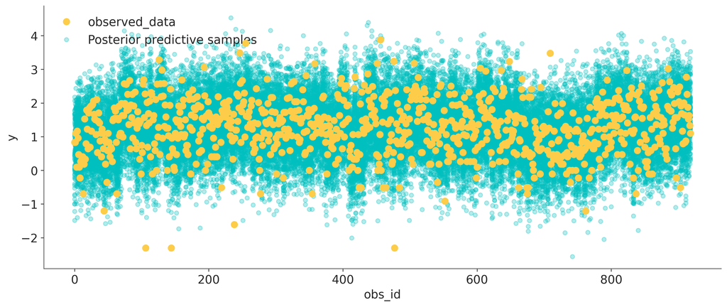

```python
az.style.use("arviz-doc")
az.plot_lm(
    y=idata.observed_data["y"],
    x=idata.observed_data["obs_id"],
    y_hat=idata.posterior_predictive["y"],
    figsize=[12, 5],
    grid=False
);
```

The function `az.loo` can quickly estimate a model’s out of sample log likelihood (which we saw above is a nice default loss function), allowing a nice numerical comparison between models.

Watch out for the `warning` column, which can tell you if the estimation is likely to be incorrect. It’s usually a good idea to set the `pointwise` argument to `True`, as this allows for more detailed analysis at the per-observation level.

```python
az.loo(idata, var_name="y", pointwise=True)
```

```
Computed from 2000 posterior samples and 919 observations log-likelihood matrix.

         Estimate       SE
elpd_loo -1027.18    28.85
p_loo       26.82        -
------

Pareto k diagnostic values:
                         Count   Pct.
(-Inf, 0.70]   (good)      919  100.0%
   (0.70, 1]   (bad)         0    0.0%
   (1, Inf)   (very bad)    0    0.0%
```

The function `az.compare` is useful for comparing different out of sample log likelihood estimates.

```python
idata.log_likelihood["fake"] = xr.DataArray(
    # generate some fake log likelihoods
    np.random.normal(0, 2, [4, 500, 919]),
    coords=idata.log_likelihood.coords,
    dims=idata.log_likelihood.dims
)
comparison = az.compare(
    {
        "real": az.loo(idata, var_name="y"),
        "fake": az.loo(idata, var_name="fake")
    }
)
comparison
```

|  | rank | elpd_loo | p_loo | elpd_diff | weight | se | dse | warning | scale |
| --- | --- | --- | --- | --- | --- | --- | --- | --- | --- |
| real | 0 | -1027.176982 | 26.817161 | 0.000000 | 0.984786 | 28.848998 | 0.000000 | False | log |
| fake | 1 | -1800.021190 | 3632.470122 | 772.844209 | 0.015214 | 3.464644 | 29.082427 | True | log |

The function [`az.plot_compare`](https://python.arviz.org/en/latest/api/generated/arviz.plot_compare.html) shows these results on a nice graph:

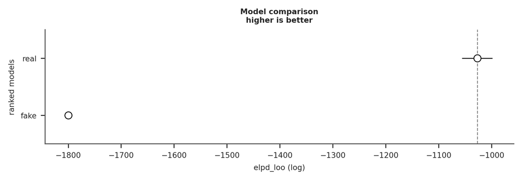

```python
az.plot_compare(comparison);
```